# Transgenic mice gene signature in human colon cancer

Lin et al

10 June, 2019

# Overview: The goals of this analysis are.

- First, we want to know what the differences in DGE and pathways between mouse model G12D vs. G13B.
- Second, we want to know how similar the mouse models are to its human counterpart.
  - this is either through similarity in genes or pathways.
  - we want to know if genes that are differentially expressed in the mouse models can be used to supervised clustering in humans.
  - we want to know if DGE in mouse can drive odd ratio of being in one group or another in human
  - wa want to know if DGE in mouse can predicit survival in human data.

# Method

- KRAS, NRAS and BRAF mutation analysis for TCGA: READ and COAD sets were downloaded from GDC without **regards to how the mutations were called** or how the samples were derived.
- KRAS mutations
- here is the breakdown for each mutation.
- All samples with BRAF or NRAS will be remove, regardless of type.
- In the plot below: mutations with a blank name means there is no a.a alteration, eg UTR

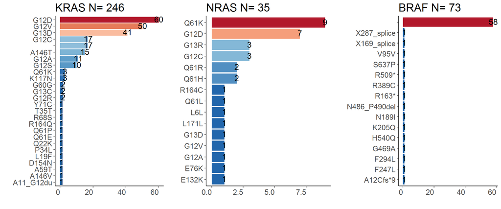

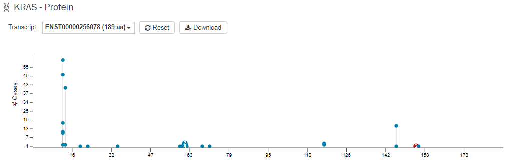

# Output results explained.

- **All results are output to a single excel file called. G12D.G13D.results.xlsx**
- mouse.key ( key for mouse data )
- pca ( An unsupervised PCA)
- mouse.G12D ( DGE between G12D vs WT)
- mouse.G13D ( DGE between G13D vs WT)
- mouse.G12D.vs.G13D ( DGE between G12D vs G13D )
- mus.gsea.compare ( GSEA found unique to each group)
- mus.ontology.compare ( Gene ontology unique to each group)
- mus.dge.compare ( DGE found unique for each group)
- DGE.mouse.human ( DGE genes match by direction in both humand and mouse)
- GSEA.mouse.human.G12D ( GSEA found in human and mouse )
- GSEA.mouse.human.G13D ( GSEA found in human and mouse )
- ONT.mouse.human.G12D ( Gene ontology found in human and mouse )
- ONT.mouse.human.G13D ( Gene ontology found in human and mouse )
- To keep the dataset harmonized I also download RNA-Seq (htseq counts) for READ and COAD from GDC as well.
- Please note that this these are total samples **NOT** unique patients. Sometimes there are replicates for whatever reason. Samples are match up to Patient->Sample->Vial this is as close as I can get to match DNA to RNA counts since after vial its portion off to different experiments.
- This corresponds to the 4th partition of the TCGA barcode.
- [TCGA barcodes explained](https://docs.gdc.cancer.gov/Encyclopedia/pages/TCGA_Barcode/)
- **total samples N=** 689

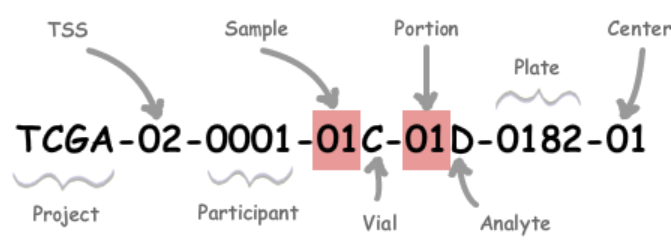

- Only **2** samples with KRAS mutations were removed due to lack of RNA.seq data.
- The total samples N= 689 , off these, 244 samples had some sort of KRAS mutation.
- There were also samples that had both NRAS+KRAS or BRAF + KRAS
- The samples below have NRAS + KRAS

TCGA.AA.A00N.01A, TCGA.DM.A1D9.01A, TCGA.DC.6160.01A, TCGA.AA.3864.01A

- BRAF + KRAS

TCGA.AM.5820.01A, TCGA.A6.6653.01A, TCGA.AD.6895.01A, TCGA.AG.3731.01A, TCGA.DM.A1D7.01A, TCGA.EI.6882.01A, TCGA.AA.3715.01A, TCGA.A6.2672.01B, TCGA.CA.6718.01A

# Grand Total

|  | barcode | a.a | consequence | DNA.change |
| --- | --- | --- | --- | --- |
| 38 | TCGA.AA.3510.01A |  | 3_prime_UTR_variant | chr12:g.25209730T>G |
| 170 | TCGA.AA.3510.01A | R164Q | missense_variant | chr12:g.25209871C>T |
| 85 | TCGA.AA.3672.01A | G60G | synonymous_variant | chr12:g.25227344A>T |
| 241 | TCGA.AA.3672.01A | Q61K | missense_variant | chr12:g.25227343G>T |
| 52 | TCGA.AG.3881.01A | Q61E | missense_variant | chr12:g.25227343G>C |
| 219 | TCGA.AG.3881.01A |  | intron_variant | chr12:g.25227341T>A |
| 89 | TCGA.AG.4008.01A | G12C | missense_variant | chr12:g.25245351C>A |
| 214 | TCGA.AG.4008.01A | G12V | missense_variant | chr12:g.25245350C>A |
| 8 | TCGA.CK.4948.01B | T35T | synonymous_variant | chr12:g.25245280T>G |
| 226 | TCGA.CK.4948.01B | G12D | missense_variant | chr12:g.25245350C>T |
| 23 | TCGA.D5.7000.01A | Q61K | missense_variant | chr12:g.25227343G>T |
| 78 | TCGA.D5.7000.01A |  | intron_variant | chr12:g.25227344A>G |
| 96 | TCGA.DM.A282.01A |  | 3_prime_UTR_variant | chr12:g.25209899delCAT |
| 125 | TCGA.DM.A282.01A | G12D | missense_variant | chr12:g.25245350C>T |
| 28 | TCGA.F4.6703.01A | G12D | missense_variant | chr12:g.25245350C>T |
| 60 | TCGA.F4.6703.01A |  | 3_prime_UTR_variant | chr12:g.25209700delT |
| 99 | TCGA.F4.6805.01A | Q61P | missense_variant | chr12:g.25227342T>G |
| 128 | TCGA.F4.6805.01A | Y71C | missense_variant | chr12:g.25227312T>C |
| 75 | TCGA.G4.6320.01A | G12D | missense_variant | chr12:g.25245350C>T |
| 149 | TCGA.G4.6320.01A | G13D | missense_variant | chr12:g.25245347C>T |
| 73 | TCGA.G5.6233.01A | G12C | missense_variant | chr12:g.25245351C>A |
| 148 | TCGA.G5.6233.01A | G12V | missense_variant | chr12:g.25245350C>A |

# Mice RNA-Seq

- Mice samples raw counts were derived with RSEM using the bowtie2 aligner
- Gene annotation and mouse genome are from genecode, GRCm38.p6 and vM18, respectively.
  - **note** group A146T was dropped by request.
- Key table
- Unsupervised PCA plot with only genes with high variance.
- low variance is uninteresting and can infleunce downstream analysis. Removal of low varaint genes can improve downstream analysis such as dimensionality reduction and clustering. To mitigate the effect of these singls, we caluclate Coefficient of variation (CoV) for each gene and only take the top 75% of the most variant genes.

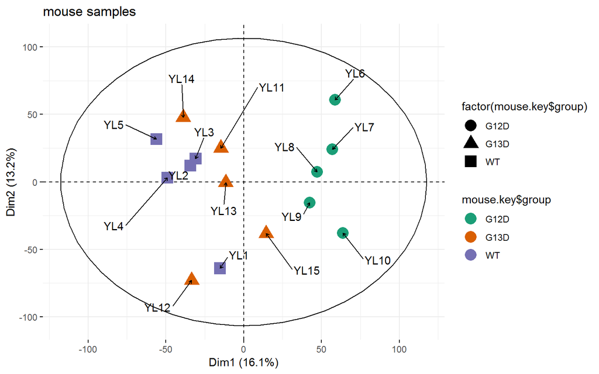

Unsupervised PCA of Mouse data

Unsupervised Hierarchical clustering

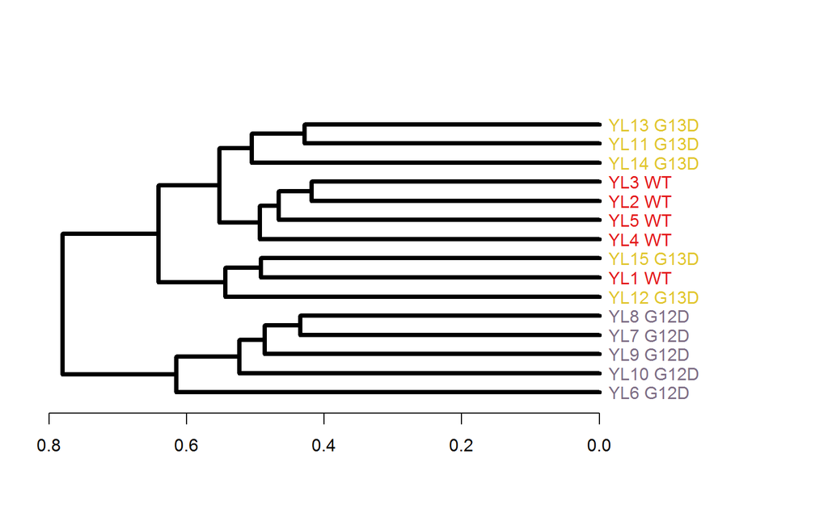

# Differential Gene Expression (DGE) in mice.

- We use limma with eBayes
- below are histograms of the results between the two comparisons.
  - G13D vs WT
  - G12D vs WT
  - G12D vs G13D
  - **All Fold changes are with respect to the mutation group**

G12D

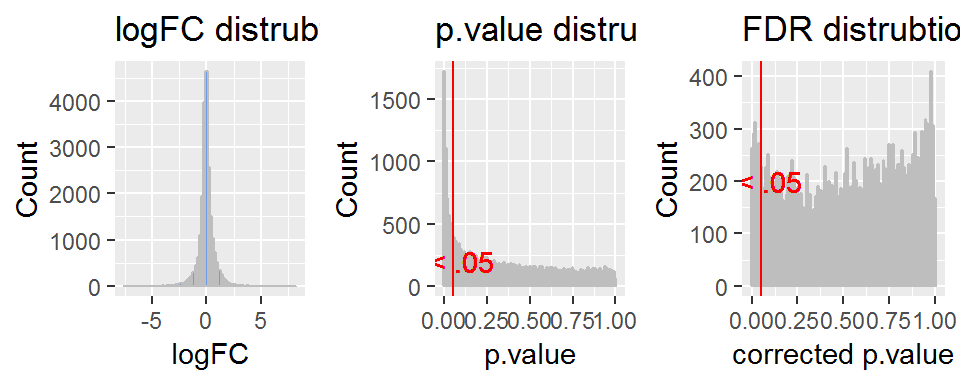

G13D

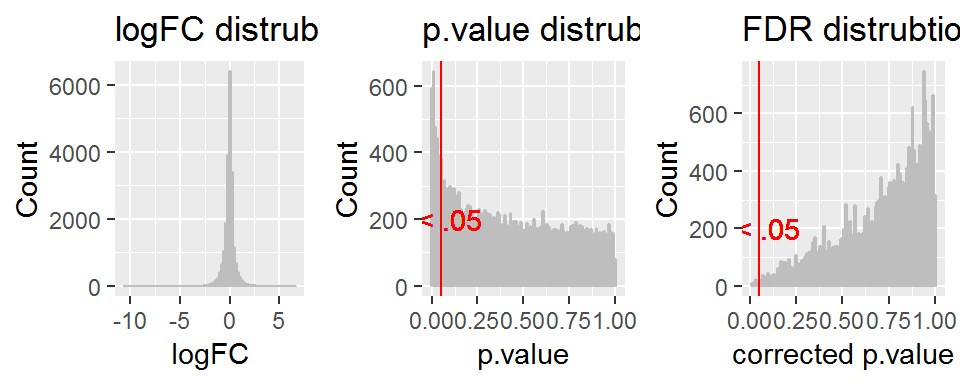

result distributions: G13D

G12D vs G13D

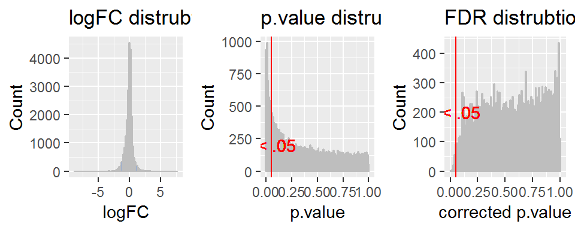

# based on the above histograms these are the filters I used to define DGE.

- these values are use to decide what filters are to be used to define DGE
  - G12D.fdr < .05
  - G12D.logfc = 1.5
  - G13D.fdr < .1
  - G13D.logfc = 1.2
  - G12D vs. G13D.logfc = 1.2
  - G12D vs. G13D.fdr < .05
- Note that these thresholds are only recommendations, obviosly you would need to decide based on biology and other biological factors. I chose these based on how well the sets term DGE are differentiate with clustering.

## Each comparison will have a total of 5 plots which will give a sense of how your data looks like after using the filters you defined earlier.

Supervised heatmap for G12D

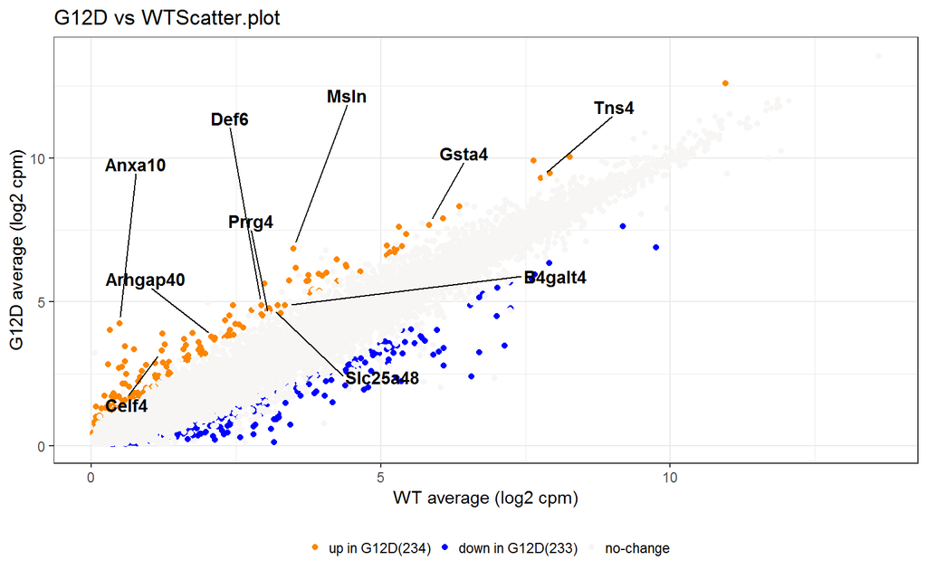

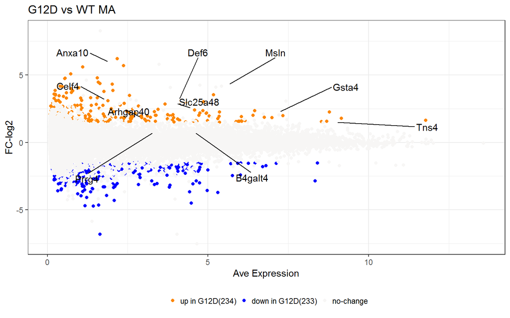

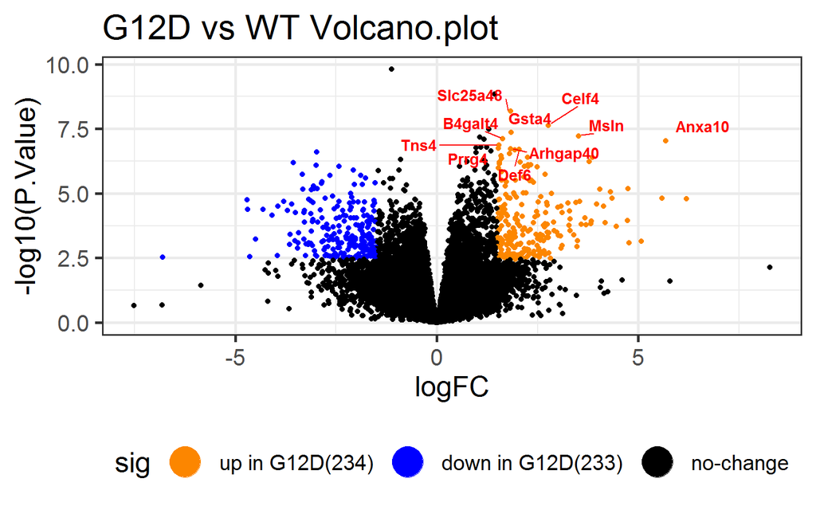

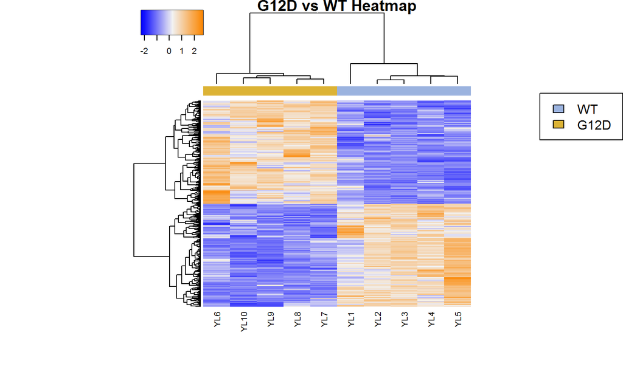

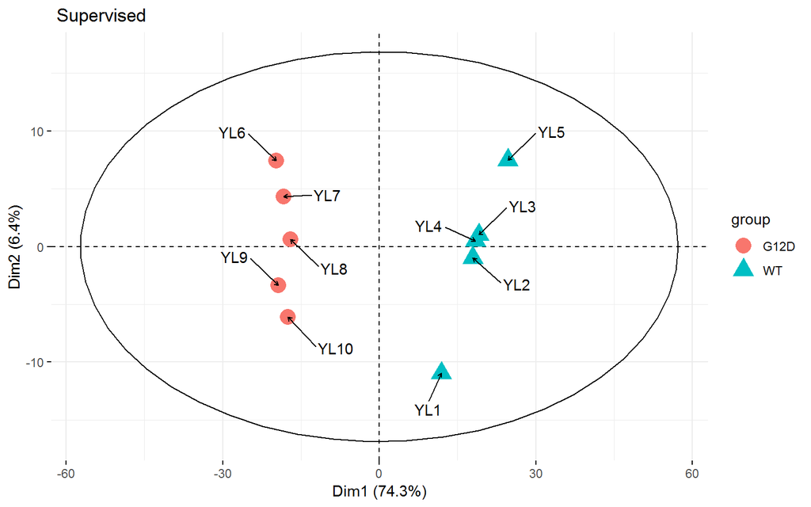

Supervised heatmap for G13D

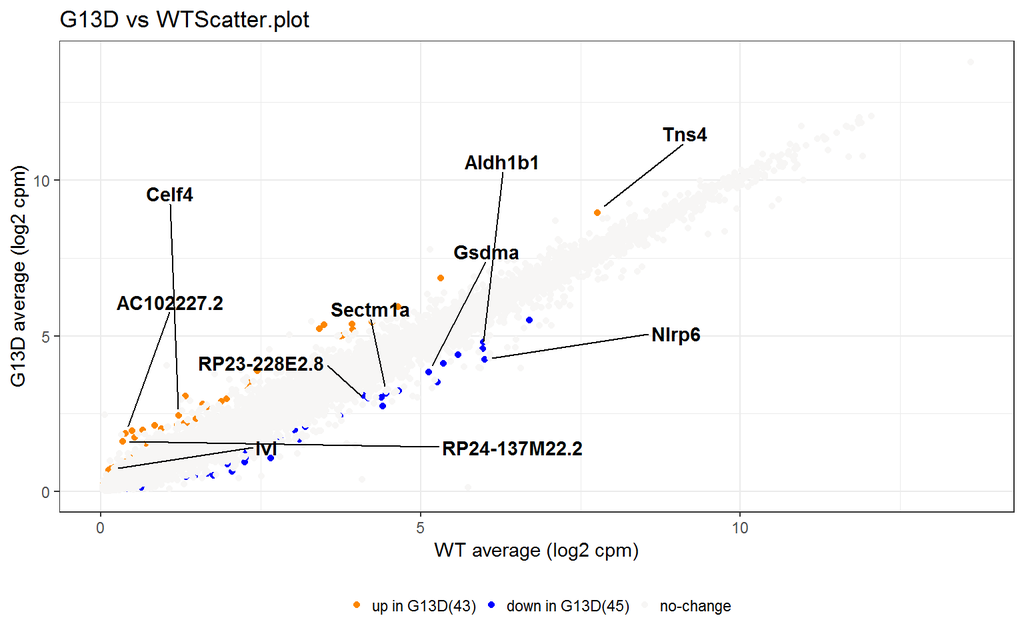

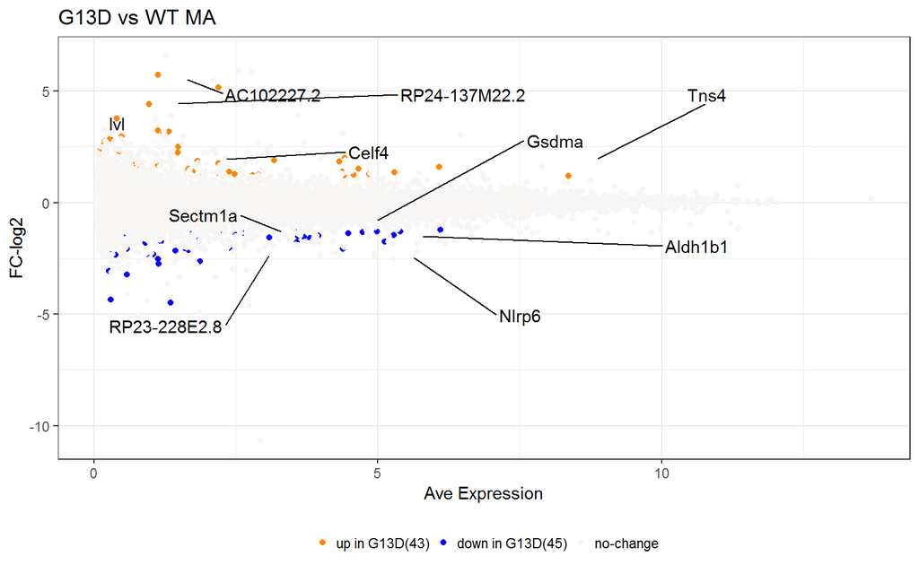

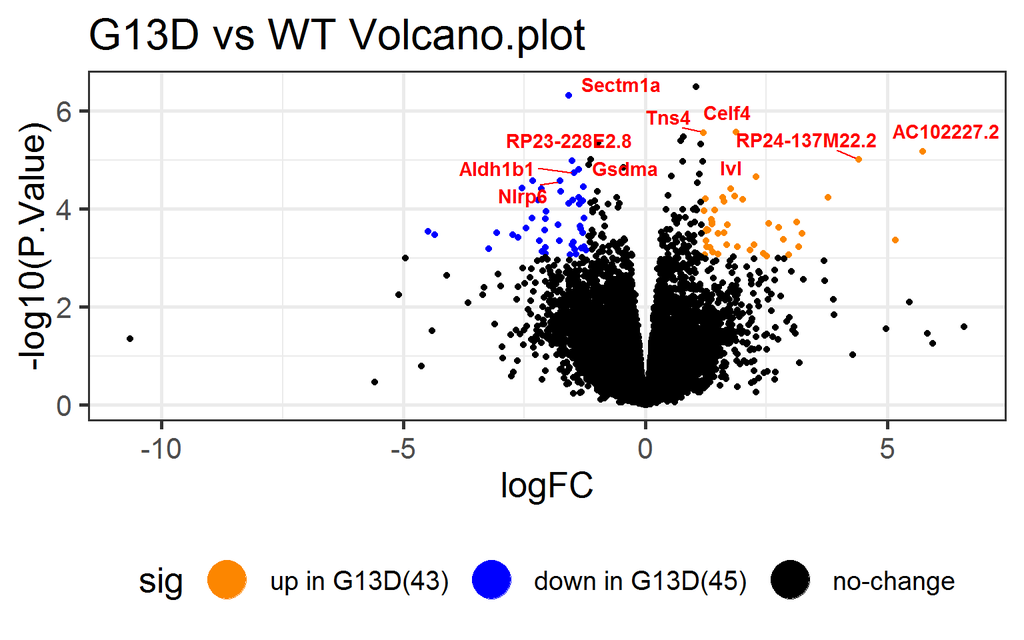

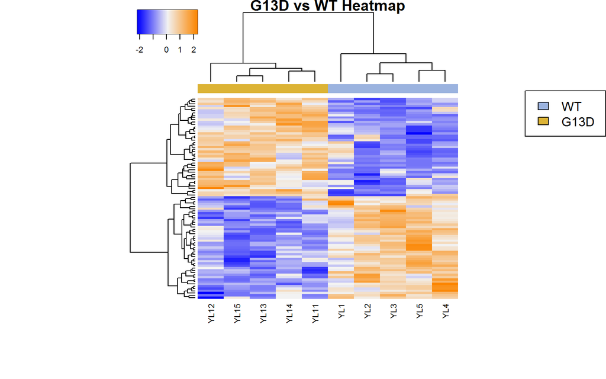

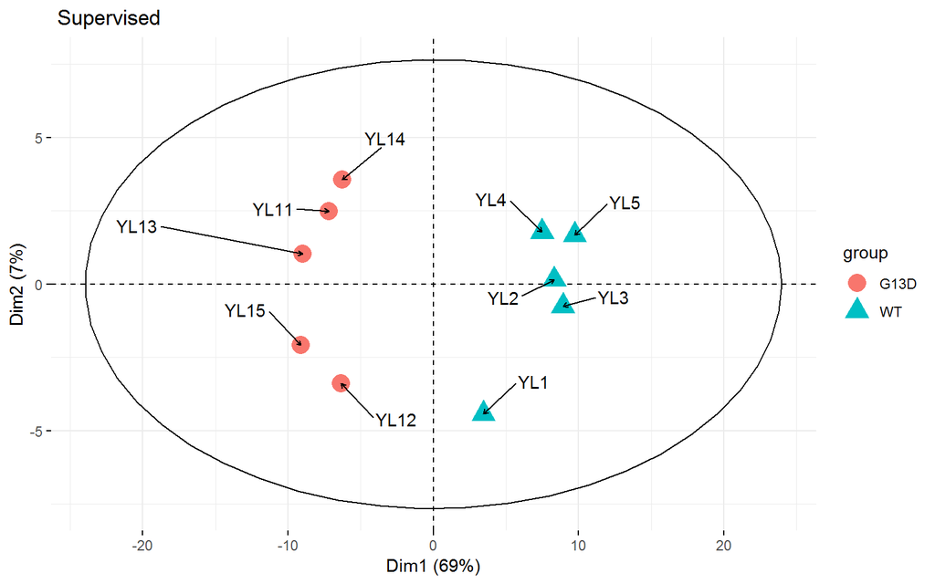

Supervised heatmap for G12D vs G13D

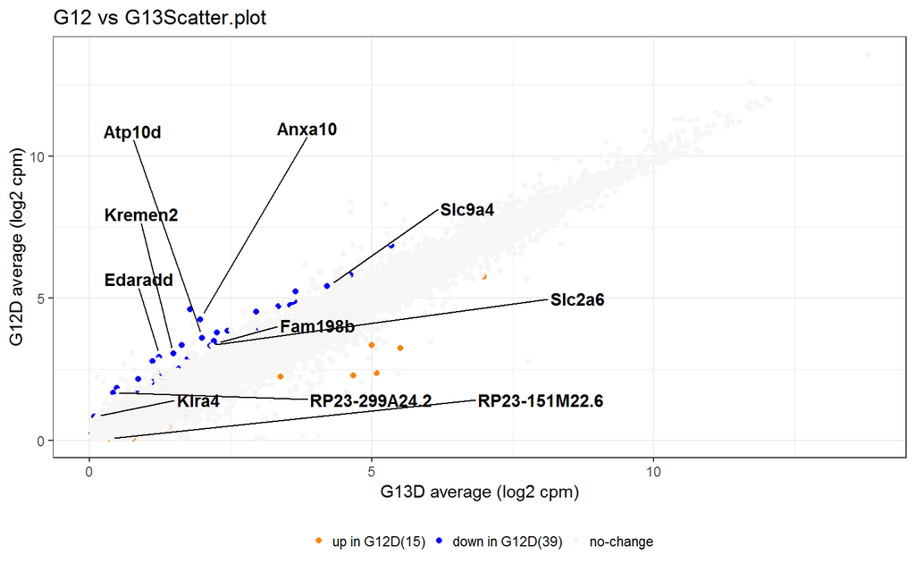

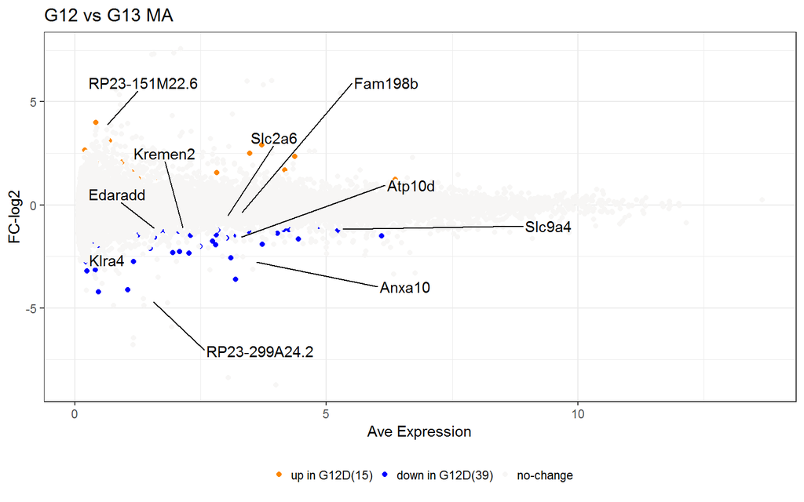

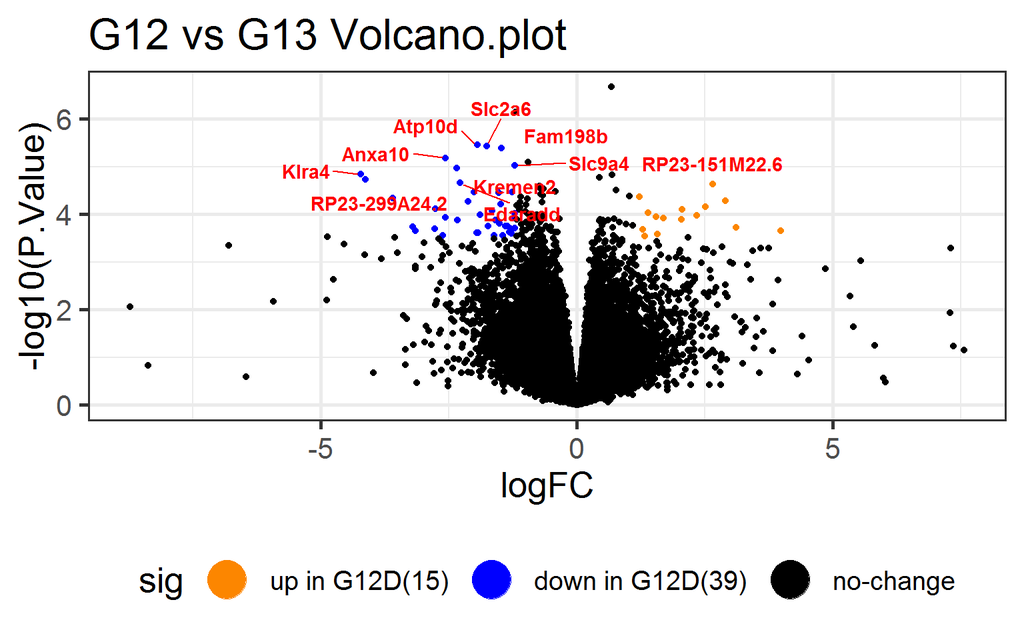

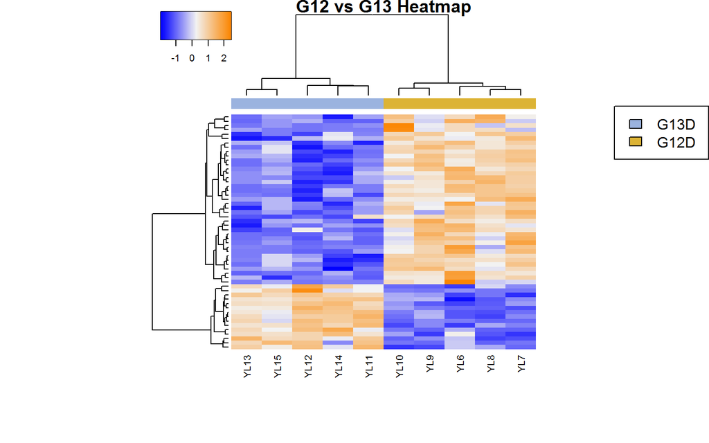

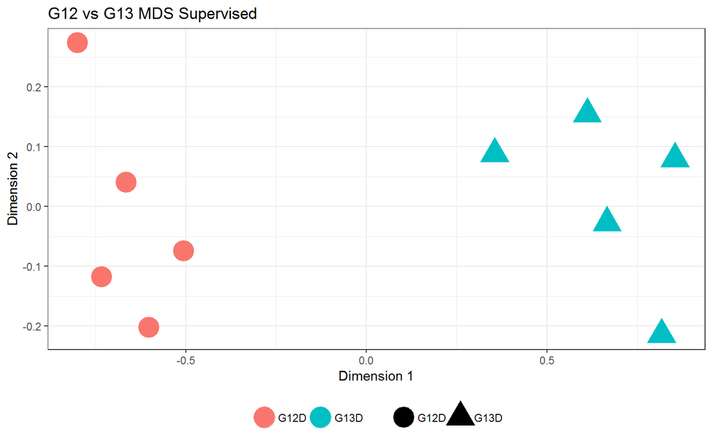

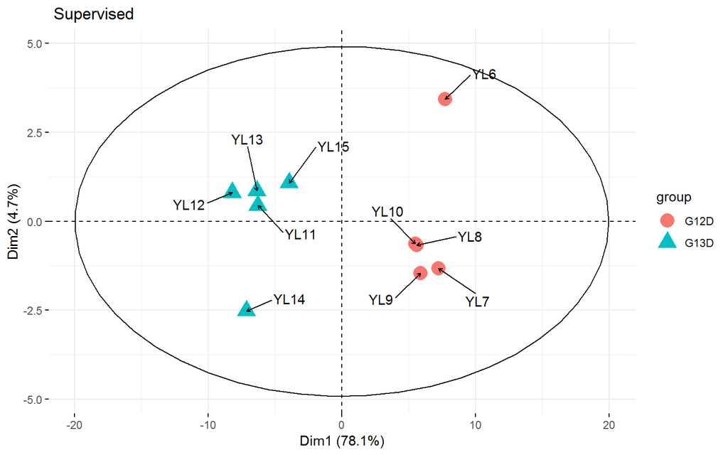

## to study the differences between G12D vs G13D we are going to compare the pathways and genes between these comparisons.

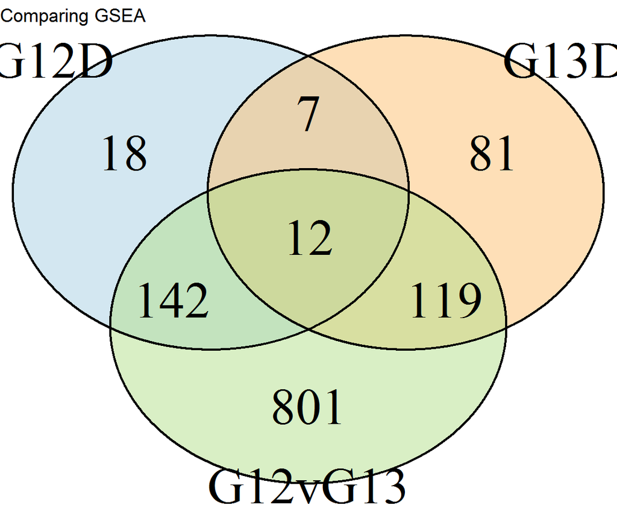

## example of some of the pathway/genes in each domain. Please see Excel sheet for the full list.

| G12D | G13D | G12vG13 | all.three |
| --- | --- | --- | --- |
| REACTOME_TRANSPORT_TO_THE_GOLGI_AND_SUBSEQUENT_MODIFICATION | REACTOME_TRANSPORT_OF_INORGANIC_CATIONS_ANIONS_AND_AMINO_ACIDS_OLIGOPEPTIDES | REACTOME_TRANSPORT_OF_MATURE_TRANSCRIPT_TO_CYTOPLASM | REACTOME_INTERFERON_GAMMA_SIGNALING |
| GO.BP_ZINC_II_ION_TRANSPORT | REACTOME_PURINE_METABOLISM | REACTOME_TRANSPORT_OF_GLUCOSE_AND_OTHER_SUGARS_BILE_SALTS_AND_ORGANIC_ACIDS_METAL_IONS_AND_AMINE_COMPOUNDS | REACTOME_GENERATION_OF_SECOND_MESSENGER_MOLECULES |
| GO.BP_RESPONSE_TO_PROSTAGLANDIN | REACTOME_GLUTATHIONE_CONJUGATION | REACTOME_TRANSLATION | REACTOME_COLLAGEN_FORMATION |
| GO.BP_REGULATION_OF_SYMBIOSIS_ENCOMPASSING_MUTUALISM_THROUGH_PARASITISM | REACTOME_FORMATION_OF_THE_TERNARY_COMPLEX_AND_SUBSEQUENTLY_THE_43S_COMPLEX | REACTOME_TRANSCRIPTION_COUPLED_NER_TC_NER | KEGG_VIRAL_MYOCARDITIS |
| GO.BP_REGULATION_OF_LEUKOCYTE_MEDIATED_CYTOTOXICITY | REACTOME_CHOLESTEROL_BIOSYNTHESIS | REACTOME_TRANSCRIPTION | KEGG_CELL_ADHESION_MOLECULES_CAMS |
| GO.BP_PROTEIN_TRIMERIZATION | REACTOME_AMINO_ACID_TRANSPORT_ACROSS_THE_PLASMA_MEMBRANE | REACTOME_TRAF6_MEDIATED_IRF7_ACTIVATION | HALLMARK_INTERFERON_GAMMA_RESPONSE |
| GO.BP_POSITIVE_REGULATION_OF_PROTEIN_KINASE_B_SIGNALING | REACTOME_AMINO_ACID_AND_OLIGOPEPTIDE_SLC_TRANSPORTERS | REACTOME_TOLL_RECEPTOR_CASCADES | HALLMARK_EPITHELIAL_MESENCHYMAL_TRANSITION |
| GO.BP_POSITIVE_REGULATION_OF_NIK_NF_KAPPAB_SIGNALING | REACTOME_ACTIVATION_OF_THE_MRNA_UPON_BINDING_OF_THE_CAP_BINDING_COMPLEX_AND_EIFS_AND_SUBSEQUENT_BINDING_TO_43S | REACTOME_TELOMERE_MAINTENANCE | HALLMARK_ALLOGRAFT_REJECTION |
| GO.BP_NEGATIVE_REGULATION_OF_LYMPHOCYTE_MEDIATED_IMMUNITY | KEGG_VASCULAR_SMOOTH_MUSCLE_CONTRACTION | REACTOME_SYNTHESIS_OF_DNA | GO.BP_RESPONSE_TO_INTERFERON_GAMMA |
| GO.BP_NEGATIVE_REGULATION_OF_LEUKOCYTE_MEDIATED_IMMUNITY | KEGG_P53_SIGNALING_PATHWAY | REACTOME_SRP_DEPENDENT_COTRANSLATIONAL_PROTEIN_TARGETING_TO_MEMBRANE | GO.BP_PHAGOCYTOSIS_ENGULFMENT |

Differences in Gene pathway ontology

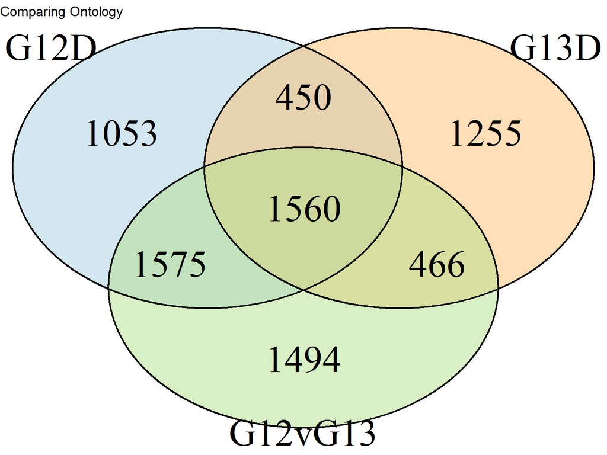

## example of some of the pathway/genes in each domain. Please see Excel sheet for the full list.

| G12D | G13D | G12vG13 | all.three |
| --- | --- | --- | --- |
| MF voltage-gated ion channel activity | MF zinc ion transmembrane transporter activity | MF Y-form DNA binding | MF UDP-galactosyltransferase activity |
| MF voltage-gated channel activity | MF voltage-gated calcium channel activity involved in bundle of | MF voltage-gated potassium channel activity involved in cardiac | MF tubulin binding |
| MF vitamin binding | MF vitamin D response element binding | MF voltage-gated calcium channel activity involved in AV node c | MF transporter activity |
| MF vitamin B6 binding | MF vitamin D binding | MF vinculin binding | MF transmembrane receptor protein tyrosine kinase activity |
| MF virus receptor activity | MF very long-chain fatty acid-CoA ligase activity | MF vascular endothelial growth factor receptor 1 binding | MF transmembrane receptor protein kinase activity |
| MF vasopressin receptor activity | MF very-low-density lipoprotein particle binding | MF vascular endothelial growth factor-activated receptor activi | MF transforming growth factor beta binding |
| MF vascular endothelial growth factor receptor binding | MF uridine kinase activity | MF unfolded protein binding | MF transferase activity, transferring glycosyl groups |
| MF uracil binding | MF UDP-glucuronate decarboxylase activity | MF ubiquitin protein ligase binding | MF transferase activity |
| MF UDP-N-acetylglucosamine-lysosomal-enzyme N-acetylglucosamine | MF ubiquitin conjugating enzyme binding | MF ubiquitin ligase inhibitor activity | MF transcription regulatory region DNA binding |
| MF UDP-glucosyltransferase activity | MF ubiquitin-specific protease binding | MF ubiquitin conjugating enzyme activity | MF transcription regulator activity |

Differences in Genet pathway ontology

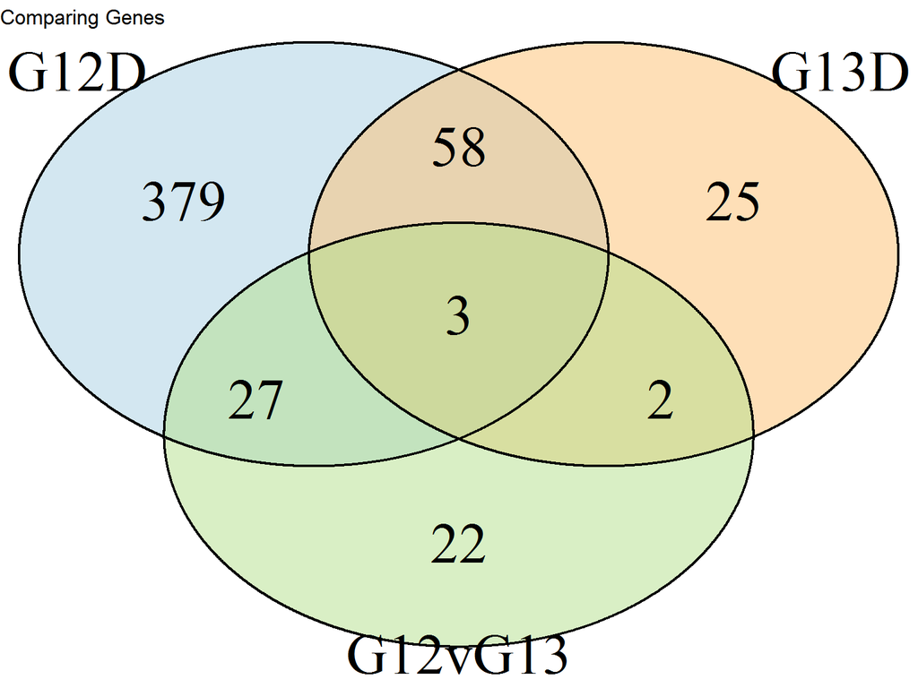

## example of some of the pathway/genes in each domain. Please see Excel sheet for the full list.

| G12D | G13D | G12vG13 | all.three |
| --- | --- | --- | --- |
| Zp2 | Wnt3 | Wasf3 | Rdh9 |
| Zfp57 | Tspan32 | Slc2a6 | Msln |
| Zfp534 | Trim58 | RP23-464D14.7 | Anxa10 |
| Zfp503 | Rpsa-ps10 | RP23-464D14.6 | . |
| Zfp365 | RP24-342G5.6 | RP23-214M22.3 | . |
| Zc3h12b | RP24-180B11.8 | RP23-205D10.4 | . |
| Wnt7b | RP23-341H2.4 | Pcsk9 | . |
| Wnt6 | RP23-324H16.2 | Notch3 | . |
| Wnt10a | Rgcc | Lockd | . |
| Vsig1 | Ppfia4 | Kremen2 | . |

## Next we ask are DGE genes specific to mutation in mouse have an impact on human? That is, do DGE’s in mouse alter the odd ratio of being in one group or another (WT vs mutation group)?

[output not shown]

**for this logit model we also corrected for age, tumor stage and race**

# significant odd ratio in human from upregulated genes in G12D mouse model

G12D upregulated

|  | Estimate | OR | p.value | gene | mut | base |
| --- | --- | --- | --- | --- | --- | --- |
| MSLN | 0.1903 | 1.2097 | 0.0040912 | MSLN | G12D | wt |
| CXCL11 | 0.1669 | 1.1817 | 0.0185595 | CXCL11 | G12D | wt |
| DSG3 | 0.1430 | 1.1538 | 0.0027400 | DSG3 | G12D | wt |
| SAMD5 | 0.1821 | 1.1998 | 0.0405572 | SAMD5 | G12D | wt |
| SLC4A11 | 0.3934 | 1.4820 | 0.0000212 | SLC4A11 | G12D | wt |
| DEF6 | 0.8507 | 2.3412 | 0.0008523 | DEF6 | G12D | wt |
| IL33 | 0.2713 | 1.3117 | 0.0017973 | IL33 | G12D | wt |
| RASAL1 | 0.4138 | 1.5125 | 0.0001251 | RASAL1 | G12D | wt |
| SHF | 0.4495 | 1.5675 | 0.0000186 | SHF | G12D | wt |
| HAS3 | 0.3101 | 1.3636 | 0.0037644 | HAS3 | G12D | wt |
| F5 | 0.2003 | 1.2218 | 0.0047498 | F5 | G12D | wt |
| TNS4 | 0.5476 | 1.7291 | 0.0000038 | TNS4 | G12D | wt |